# Taller evaluable - COVID19

Juan Gabriel Gomila

3/24/2020

En este ejercicio vamos a analizar los casos documentados de Corona Virus (COVID-19) en diferentes regiones del mundo. Los datos originales los podéis encontrar en [Kaggle](https://www.kaggle.com/imdevskp/corona-virus-report), el portal de conjuntos de datos para analizar (que de hecho tienen competiciones con premios de hasta un millón de dólares!).

Cuando tengas que imprimir una tabla `x` por pantalla, utiliza la función `kable(x)` del paquete `knitr` para que al imprimirla te salga bonita en el documento final.

## Carga y análisis exploratorio inicial

1. Carga el dataset adjunto al taller evaluable correctamente.
- ¿Qué tipo de fichero es? ¿Cómo se llama ese tipo de fichero y qué lo caracteriza?
- Consulta su estructura con la función adecuada de `R` e indica de qué tipo de dato se trata cada columna.

```r
datos = read.csv("covid_19_clean_complete.csv")
str(datos)
```

```
## 'data.frame':    17136 obs. of  8 variables:
##  $ Province.State: Factor w/ 79 levels "","Alberta","Anguilla",..: 1 1 1 1 1 1 1 1 6 48 ...
##  $ Country.Region: Factor w/ 177 levels "Afghanistan",..: 1 2 3 4 5 6 7 8 9 9 ...
##  $ Lat           : num  33 41.2 28 42.5 -11.2 ...
##  $ Long          : num  65 20.17 1.66 1.52 17.87 ...
##  $ Date          : Factor w/ 68 levels "1/22/20","1/23/20",..: 1 1 1 1 1 1 1 1 1 1 ...
##  $ Confirmed     : int  0 0 0 0 0 0 0 0 0 0 ...
##  $ Deaths        : int  0 0 0 0 0 0 0 0 0 0 ...
##  $ Recovered     : int  0 0 0 0 0 0 0 0 0 0 ...
```

2. Cambia el nombre de las columnas para que esten en castellano utilizando la siguiente nomenclatura:
- Provincia_Estado
- Pais_Region
- Latitud
- Longitud
- Fecha
- Casos_Confirmados
- Muertos
- Recuperados

Haz un `head` de la tabla para mostrarme los 10 primeros elementos y que realmente has hecho el cambio. A partir de ahora en el resto de ejercicios utilizaremos esta nueva tabla para que sea más fácil de entender y analizar.

```r
colnames(datos) = c("Provincia_Estado",
                    "Pais_Region",
                    "Latitud",
                    "Longitud",
                    "Fecha",
                    "Casos_Confirmados",
                    "Muertos",
                    "Recuperados"
                    )
knitr::kable(head(datos))
```

| Provincia_Estado | Pais_Region | Latitud | Longitud | Fecha | Casos_Confirmados | Muertos | Recuperados |
| --- | --- | --- | --- | --- | --- | --- | --- |
|  | Afghanistan | 33.0000 | 65.0000 | 1/22/20 | 0 | 0 | 0 |
|  | Albania | 41.1533 | 20.1683 | 1/22/20 | 0 | 0 | 0 |
|  | Algeria | 28.0339 | 1.6596 | 1/22/20 | 0 | 0 | 0 |
|  | Andorra | 42.5063 | 1.5218 | 1/22/20 | 0 | 0 | 0 |
|  | Angola | -11.2027 | 17.8739 | 1/22/20 | 0 | 0 | 0 |
|  | Antigua and Barbuda | 17.0608 | -61.7964 | 1/22/20 | 0 | 0 | 0 |

3. Algunas de estas columnas deberían ser datos cualitativos, algunos datos ordinales y otros datos cuantitativos. Justifica cual debería ser el tipo de dato de **cada columna** y haz la conversión adecuada utilizando las funciones adecuadas para ello. Haz un `str` al final para mostrar que has efectuado todos los cambios solicitados.

```r
datos$Provincia_Estado = ordered(datos$Provincia_Estado)
datos$Pais_Region = ordered(datos$Pais_Region)
```

4. Hay unos cuantos tipos especial de datos
- **Las fechas**. Justifica a qué tipo de datos (ordinal, cualitativo o cuantitativo) se parece más.
- Utiliza la función `as.Date` para convertir la columna de la fecha a dicho formato. Pista: investiga la documentación de la función anterior para ver cómo usar el parámetro `format` para conseguirlo.

```r
datos$Fecha = as.Date(datos$Fecha,format="%m/%d/%y" )
```

- **Datos anómalos**. El número de casos documentados (confirmados, muertos o recuperados) debería ser un número natural (cero o positivo). Se supone que debería verificarse la ecuación siguiente:

$$Casos\ Confirmados = Muertos + Recuperados + Enfermos$$
* Utiliza la ecuación anterior para añadir una nueva columna llamada `Enfermos` que calcule el valor a partir de la ecuación anterior, y comprueba que los valores tienen sentido.

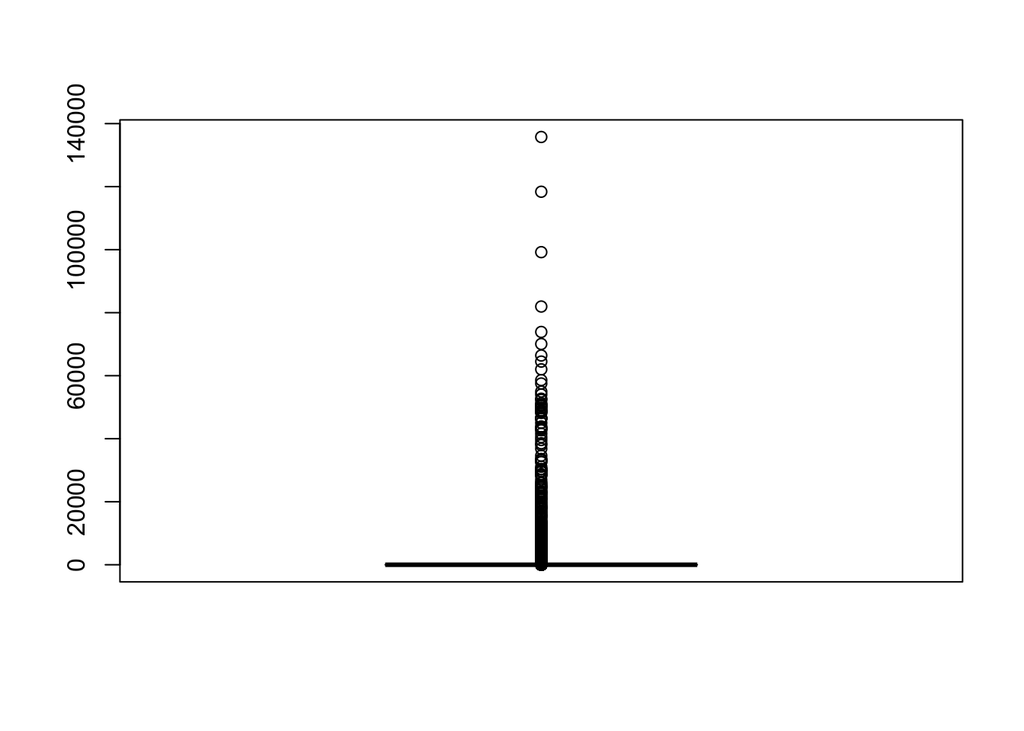

```r
datos$Enfermos = datos$Casos_Confirmados - datos$Muertos - datos$Recuperados
boxplot(datos$Enfermos)
```

## Análisis geográfico

5. Crea un nuevo dataset `datos_europa` a partir de filtrar el dataset original para quedarte únicamente con los valores correspondiedose a los paises de **Europa Occidental**, que se hallan más allá de las latitudes 38ºN y entre las longitudes 20ºW y 40ºE (te recuerdo que las latitudes del sur y del oeste son negativas y las del norte y el este son positivas). Indica cuantas filas de datos pertenecen a observaciones de Europa utilizando alguna de las funciones vistas en clase.

```r
datos_europa = datos[datos$Lat > 38 & datos$Long > -20 & datos$Long < 40, ]
nrow(datos_europa)
```

```
## [1] 3196
```

6. Hace un mes, el profesor estuvo en Potsdam, Alemania. Vamos a ver si tuvo muchas posibilidades de contagio en su estancia. Para ello sigue los tres siguientes pasos:
- Crea una función que dadas dos ubicaciones geográficas `x=(lat1, long1)` y `y=(lat2, long2)`, calcule la distancia en grados entre esos dos lugares utilizando la fórmula

$$d(x,y) = \sqrt{(lat1 - lat2)^2 + (long1-long2)^2}.$$

```r
dist <- function(lat1, long1, lat2, long2){
  return(sqrt((lat1-lat2)^2+(long1- long2)^2))
}
```

- Calcula la distancia de cada observación de Corona Virus a Potsdam con la función Anterior. Potsdam se halla en las coordenadas geográficas 52.3988609 de latitud Norte y 13.0656605 longitud Este. Añadelo como nueva columna a tu conjunto de datos original (la puedes llamar dist_potsdam)

```r
datos_europa$dist_potsdam = dist(datos_europa$Latitud, datos_europa$Longitud, 52.3988609, 13.0656605)
head(datos_europa)
```

```
##    Provincia_Estado            Pais_Region Latitud Longitud      Fecha
## 2                                  Albania 41.1533  20.1683 2020-01-22
## 4                                  Andorra 42.5063   1.5218 2020-01-22
## 17                                 Austria 47.5162  14.5501 2020-01-22
## 23                                 Belarus 53.7098  27.9534 2020-01-22
## 24                                 Belgium 50.8333   4.0000 2020-01-22
## 28                  Bosnia and Herzegovina 43.9159  17.6791 2020-01-22
##    Casos_Confirmados Muertos Recuperados Enfermos dist_potsdam
## 2                  0       0           0        0    13.300757
## 4                  0       0           0        0    15.202746
## 17                 0       0           0        0     5.103326
## 23                 0       0           0        0    14.945345
## 24                 0       0           0        0     9.199847
## 28                 0       0           0        0     9.656317
```

```r
knitr::kable(datos_europa[datos_europa$dist_potsdam<4,])
```

|  | Provincia_Estado | Pais_Region | Latitud | Longitud | Fecha | Casos_Confirmados | Muertos | Recuperados | Enfermos | dist_potsdam |
| --- | --- | --- | --- | --- | --- | --- | --- | --- | --- | --- |
| 92 |  | Czechia | 49.8175 | 15.473 | 2020-01-22 | 0 | 0 | 0 | 0 | 3.529689 |
| 344 |  | Czechia | 49.8175 | 15.473 | 2020-01-23 | 0 | 0 | 0 | 0 | 3.529689 |
| 596 |  | Czechia | 49.8175 | 15.473 | 2020-01-24 | 0 | 0 | 0 | 0 | 3.529689 |
| 848 |  | Czechia | 49.8175 | 15.473 | 2020-01-25 | 0 | 0 | 0 | 0 | 3.529689 |
| 1100 |  | Czechia | 49.8175 | 15.473 | 2020-01-26 | 0 | 0 | 0 | 0 | 3.529689 |
| 1352 |  | Czechia | 49.8175 | 15.473 | 2020-01-27 | 0 | 0 | 0 | 0 | 3.529689 |
| 1604 |  | Czechia | 49.8175 | 15.473 | 2020-01-28 | 0 | 0 | 0 | 0 | 3.529689 |
| 1856 |  | Czechia | 49.8175 | 15.473 | 2020-01-29 | 0 | 0 | 0 | 0 | 3.529689 |
| 2108 |  | Czechia | 49.8175 | 15.473 | 2020-01-30 | 0 | 0 | 0 | 0 | 3.529689 |
| 2360 |  | Czechia | 49.8175 | 15.473 | 2020-01-31 | 0 | 0 | 0 | 0 | 3.529689 |
| 2612 |  | Czechia | 49.8175 | 15.473 | 2020-02-01 | 0 | 0 | 0 | 0 | 3.529689 |
| 2864 |  | Czechia | 49.8175 | 15.473 | 2020-02-02 | 0 | 0 | 0 | 0 | 3.529689 |
| 3116 |  | Czechia | 49.8175 | 15.473 | 2020-02-03 | 0 | 0 | 0 | 0 | 3.529689 |
| 3368 |  | Czechia | 49.8175 | 15.473 | 2020-02-04 | 0 | 0 | 0 | 0 | 3.529689 |
| 3620 |  | Czechia | 49.8175 | 15.473 | 2020-02-05 | 0 | 0 | 0 | 0 | 3.529689 |
| 3872 |  | Czechia | 49.8175 | 15.473 | 2020-02-06 | 0 | 0 | 0 | 0 | 3.529689 |
| 4124 |  | Czechia | 49.8175 | 15.473 | 2020-02-07 | 0 | 0 | 0 | 0 | 3.529689 |
| 4376 |  | Czechia | 49.8175 | 15.473 | 2020-02-08 | 0 | 0 | 0 | 0 | 3.529689 |
| 4628 |  | Czechia | 49.8175 | 15.473 | 2020-02-09 | 0 | 0 | 0 | 0 | 3.529689 |
| 4880 |  | Czechia | 49.8175 | 15.473 | 2020-02-10 | 0 | 0 | 0 | 0 | 3.529689 |
| 5132 |  | Czechia | 49.8175 | 15.473 | 2020-02-11 | 0 | 0 | 0 | 0 | 3.529689 |
| 5384 |  | Czechia | 49.8175 | 15.473 | 2020-02-12 | 0 | 0 | 0 | 0 | 3.529689 |
| 5636 |  | Czechia | 49.8175 | 15.473 | 2020-02-13 | 0 | 0 | 0 | 0 | 3.529689 |
| 5888 |  | Czechia | 49.8175 | 15.473 | 2020-02-14 | 0 | 0 | 0 | 0 | 3.529689 |
| 6140 |  | Czechia | 49.8175 | 15.473 | 2020-02-15 | 0 | 0 | 0 | 0 | 3.529689 |
| 6392 |  | Czechia | 49.8175 | 15.473 | 2020-02-16 | 0 | 0 | 0 | 0 | 3.529689 |
| 6644 |  | Czechia | 49.8175 | 15.473 | 2020-02-17 | 0 | 0 | 0 | 0 | 3.529689 |
| 6896 |  | Czechia | 49.8175 | 15.473 | 2020-02-18 | 0 | 0 | 0 | 0 | 3.529689 |
| 7148 |  | Czechia | 49.8175 | 15.473 | 2020-02-19 | 0 | 0 | 0 | 0 | 3.529689 |
| 7400 |  | Czechia | 49.8175 | 15.473 | 2020-02-20 | 0 | 0 | 0 | 0 | 3.529689 |
| 7652 |  | Czechia | 49.8175 | 15.473 | 2020-02-21 | 0 | 0 | 0 | 0 | 3.529689 |
| 7904 |  | Czechia | 49.8175 | 15.473 | 2020-02-22 | 0 | 0 | 0 | 0 | 3.529689 |
| 8156 |  | Czechia | 49.8175 | 15.473 | 2020-02-23 | 0 | 0 | 0 | 0 | 3.529689 |
| 8408 |  | Czechia | 49.8175 | 15.473 | 2020-02-24 | 0 | 0 | 0 | 0 | 3.529689 |
| 8660 |  | Czechia | 49.8175 | 15.473 | 2020-02-25 | 0 | 0 | 0 | 0 | 3.529689 |
| 8912 |  | Czechia | 49.8175 | 15.473 | 2020-02-26 | 0 | 0 | 0 | 0 | 3.529689 |
| 9164 |  | Czechia | 49.8175 | 15.473 | 2020-02-27 | 0 | 0 | 0 | 0 | 3.529689 |
| 9416 |  | Czechia | 49.8175 | 15.473 | 2020-02-28 | 0 | 0 | 0 | 0 | 3.529689 |
| 9668 |  | Czechia | 49.8175 | 15.473 | 2020-02-29 | 0 | 0 | 0 | 0 | 3.529689 |
| 9920 |  | Czechia | 49.8175 | 15.473 | 2020-03-01 | 3 | 0 | 0 | 3 | 3.529689 |
| 10172 |  | Czechia | 49.8175 | 15.473 | 2020-03-02 | 3 | 0 | 0 | 3 | 3.529689 |
| 10424 |  | Czechia | 49.8175 | 15.473 | 2020-03-03 | 5 | 0 | 0 | 5 | 3.529689 |
| 10676 |  | Czechia | 49.8175 | 15.473 | 2020-03-04 | 8 | 0 | 0 | 8 | 3.529689 |
| 10928 |  | Czechia | 49.8175 | 15.473 | 2020-03-05 | 12 | 0 | 0 | 12 | 3.529689 |
| 11180 |  | Czechia | 49.8175 | 15.473 | 2020-03-06 | 18 | 0 | 0 | 18 | 3.529689 |
| 11432 |  | Czechia | 49.8175 | 15.473 | 2020-03-07 | 19 | 0 | 0 | 19 | 3.529689 |
| 11684 |  | Czechia | 49.8175 | 15.473 | 2020-03-08 | 31 | 0 | 0 | 31 | 3.529689 |
| 11936 |  | Czechia | 49.8175 | 15.473 | 2020-03-09 | 31 | 0 | 0 | 31 | 3.529689 |
| 12188 |  | Czechia | 49.8175 | 15.473 | 2020-03-10 | 41 | 0 | 0 | 41 | 3.529689 |
| 12440 |  | Czechia | 49.8175 | 15.473 | 2020-03-11 | 91 | 0 | 0 | 91 | 3.529689 |
| 12692 |  | Czechia | 49.8175 | 15.473 | 2020-03-12 | 94 | 0 | 0 | 94 | 3.529689 |
| 12944 |  | Czechia | 49.8175 | 15.473 | 2020-03-13 | 141 | 0 | 0 | 141 | 3.529689 |
| 13196 |  | Czechia | 49.8175 | 15.473 | 2020-03-14 | 189 | 0 | 0 | 189 | 3.529689 |
| 13448 |  | Czechia | 49.8175 | 15.473 | 2020-03-15 | 253 | 0 | 0 | 253 | 3.529689 |
| 13700 |  | Czechia | 49.8175 | 15.473 | 2020-03-16 | 298 | 0 | 3 | 295 | 3.529689 |
| 13952 |  | Czechia | 49.8175 | 15.473 | 2020-03-17 | 396 | 0 | 3 | 393 | 3.529689 |
| 14204 |  | Czechia | 49.8175 | 15.473 | 2020-03-18 | 464 | 0 | 3 | 461 | 3.529689 |
| 14456 |  | Czechia | 49.8175 | 15.473 | 2020-03-19 | 694 | 0 | 3 | 691 | 3.529689 |
| 14708 |  | Czechia | 49.8175 | 15.473 | 2020-03-20 | 833 | 0 | 4 | 829 | 3.529689 |
| 14960 |  | Czechia | 49.8175 | 15.473 | 2020-03-21 | 995 | 0 | 6 | 989 | 3.529689 |
| 15212 |  | Czechia | 49.8175 | 15.473 | 2020-03-22 | 1120 | 1 | 6 | 1113 | 3.529689 |
| 15464 |  | Czechia | 49.8175 | 15.473 | 2020-03-23 | 1236 | 1 | 6 | 1229 | 3.529689 |
| 15716 |  | Czechia | 49.8175 | 15.473 | 2020-03-24 | 1394 | 3 | 10 | 1381 | 3.529689 |
| 15968 |  | Czechia | 49.8175 | 15.473 | 2020-03-25 | 1654 | 6 | 10 | 1638 | 3.529689 |
| 16220 |  | Czechia | 49.8175 | 15.473 | 2020-03-26 | 1925 | 9 | 10 | 1906 | 3.529689 |
| 16472 |  | Czechia | 49.8175 | 15.473 | 2020-03-27 | 2279 | 9 | 11 | 2259 | 3.529689 |
| 16724 |  | Czechia | 49.8175 | 15.473 | 2020-03-28 | 2631 | 11 | 11 | 2609 | 3.529689 |
| 16976 |  | Czechia | 49.8175 | 15.473 | 2020-03-29 | 2817 | 16 | 11 | 2790 | 3.529689 |

- Teniendo en cuenta que estuvo allí entre los días 2 y 7 de Marzo, ¿tendría que estar preocupado de haber estado expuesto al virus?
7. Muestra el top 15 de país/región con más proporción de muertos (la cual definiremos como, fijada una fecha, el número de muertos dividido por número de casos confirmados por país/región), desde el que tiene mayor proporción de casos al que tiene menos.
- Elige la fecha del 29 de Marzo para hacer el cálculo anterior.
- Debes excluir de top los países con número de casos confirmados a cero (si no te saldrá una proporción infinito).
- ¿En qué posición del ranking queda España? ¿Y China, el país donde se originó el COVID-19? Comenta los resultados obtenidos acerca de los países que aparecen en el ranking y por qué.

```r
datos_por_pais = aggregate(cbind(Casos_Confirmados,Muertos,Recuperados ) ~ Pais_Region,
                      data = datos[datos$Fecha==as.Date("3/29/2020", format="%m/%d/%y"),],
                      FUN = sum)
datos_por_pais$prop = datos_por_pais$Muertos/datos_por_pais$Casos_Confirmados
datos_por_pais = datos_por_pais[order(datos_por_pais$prop,decreasing = T),]

head(datos_por_pais[datos_por_pais$prop<Inf,],20)
```

```
##          Pais_Region Casos_Confirmados Muertos Recuperados       prop
## 5             Angola                 7       2           0 0.28571429
## 62            Gambia                 4       1           0 0.25000000
## 119        Nicaragua                 4       1           0 0.25000000
## 28        Cabo Verde                 6       1           0 0.16666667
## 153            Sudan                 6       1           0 0.16666667
## 61             Gabon                 7       1           0 0.14285714
## 177         Zimbabwe                 7       1           0 0.14285714
## 71            Guyana                 8       1           0 0.12500000
## 157            Syria                 9       1           0 0.11111111
## 83             Italy             97689   10779       13030 0.11033996
## 14        Bangladesh                48       5          15 0.10416667
## 140       San Marino               224      22           6 0.09821429
## 38  Congo (Kinshasa)                65       6           2 0.09230769
## 78         Indonesia              1285     114          64 0.08871595
## 151            Spain             80110    6803       14709 0.08492073
## 80              Iraq               547      42         143 0.07678245
## 117      Netherlands             10930     772         253 0.07063129
## 79              Iran             38309    2640       12391 0.06891331
## 51             Egypt               609      40         132 0.06568144
## 60            France             40708    2611        7226 0.06413973
```

8. Convierte las latitudes y longitudes a datos numéricos agrupados haciendo uso de la función cut, para ello:
- Utiliza la Regla de Scott para dividir las latitudes y la de Sturges, para dividir las longitudes indicando en todo caso el valor de la amplitud de corte utilizada así como el número de clases que sale en cada caso.
- Utiliza esos datos agrupados para hacer una tabla de contingencia que muestre cada grupo de latitudes en fila, y grupo de longitudes en columna y que cuente el número de filas del data set en cada combinación de latitud y longitud.
- Localiza la latitud y longitud agrupada donde hay más filas del data set.

```r
datos$lat_class = cut(datos$Lat, breaks = nclass.scott(datos$Lat))
datos$long_class = cut(datos$Long, breaks = nclass.Sturges(datos$Long))
tt = table(datos$lat_class, datos$long_class)
tt = tt[nrow(tt):1, ]
t(tt)
```

```
##
##                 (68.5,71.8] (65.2,68.5] (62,65.2] (58.8,62] (55.5,58.8]
##   (-135,-115]             0           0       136         0           0
##   (-115,-95.9]            0           0         0         0           0
##   (-95.9,-76.3]           0           0         0         0           0
##   (-76.3,-56.7]           0           0         0         0           0
##   (-56.7,-37.2]          68           0         0         0           0
##   (-37.2,-17.6]           0           0        68         0           0
##   (-17.6,1.97]            0           0         0        68           0
##   (1.97,21.5]             0           0        68        68          68
##   (21.5,41.1]             0           0        68         0         136
##   (41.1,60.7]             0           0         0         0           0
##   (60.7,80.2]             0           0         0         0           0
##   (80.2,99.8]             0           0         0        68           0
##   (99.8,119]              0           0         0         0           0
##   (119,139]               0           0         0         0           0
##   (139,158]               0           0         0         0           0
##   (158,178]               0           0         0         0           0
##
##                 (52.3,55.5] (49.1,52.3] (45.8,49.1] (42.6,45.8] (39.4,42.6]
##   (-135,-115]            68          68           0           0           0
##   (-115,-95.9]          136           0           0           0           0
##   (-95.9,-76.3]           0          68           0           0           0
##   (-76.3,-56.7]         136           0         136          68           0
##   (-56.7,-37.2]           0           0           0           0           0
##   (-37.2,-17.6]           0           0           0           0           0
##   (-17.6,1.97]          204          68           0           0         204
##   (1.97,21.5]             0         408         476         408         272
##   (21.5,41.1]           136           0         204          68          68
##   (41.1,60.7]             0           0           0           0         204
##   (60.7,80.2]             0           0          68           0         136
##   (80.2,99.8]             0           0           0           0          68
##   (99.8,119]              0           0          68          68         136
##   (119,139]               0           0          68          68          68
##   (139,158]               0           0           0           0           0
##   (158,178]               0           0           0           0           0
##
##                 (36.1,39.4] (32.9,36.1] (29.7,32.9] (26.4,29.7] (23.2,26.4]
##   (-135,-115]            68           0           0           0           0
##   (-115,-95.9]            0           0           0           0          68
```

[output cut: 89 more lines]

```
##   (-115,-95.9]            0           0             0
##   (-95.9,-76.3]           0           0             0
##   (-76.3,-56.7]           0          68            68
##   (-56.7,-37.2]          68           0             0
##   (-37.2,-17.6]           0           0             0
##   (-17.6,1.97]            0           0             0
##   (1.97,21.5]             0           0             0
##   (21.5,41.1]             0           0             0
##   (41.1,60.7]             0           0             0
##   (60.7,80.2]             0           0             0
##   (80.2,99.8]             0           0             0
##   (99.8,119]             68           0             0
##   (119,139]              68           0             0
##   (139,158]              68         136            68
##   (158,178]               0           0            68
```

[figure not shown]

```r
mosaicplot(t(tt),shade = T)
```

## Análisis de tiempo

9. Crea un diagrama que muestre la evolución de número por día del número de casos confirmados, número de muertos y recuperados.
- El diagrama que elijas debe mostrar los tres datos a la vez, así que intenta exprimirte el cerebro para conseguir un gráfico chulo!
- Haz que el eje de las y esté en escala logarítmica para apreciar mejor el crecimiento del número de casos.
- No te olvides de añadir una leyenda que documente los casos correctamente.

```r
datos_por_fecha = aggregate(
  cbind(Casos_Confirmados,Muertos,Recuperados ) ~ Fecha,
  data = datos,
  FUN = sum)


head(datos_por_fecha)
```

```
##        Fecha Casos_Confirmados Muertos Recuperados
## 1 2020-01-22               555      17          28
## 2 2020-01-23               654      18          30
## 3 2020-01-24               941      26          36
## 4 2020-01-25              1434      42          39
## 5 2020-01-26              2118      56          52
## 6 2020-01-27              2927      82          61
```

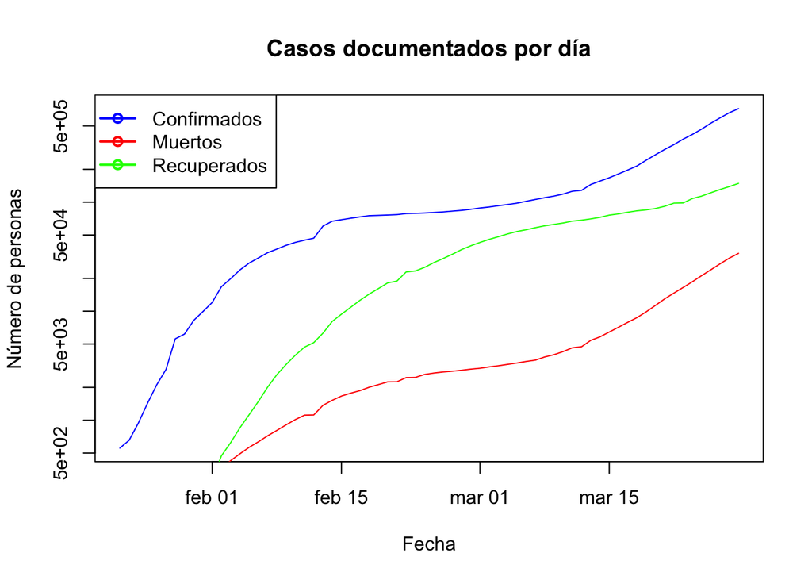

```r
plot(Casos_Confirmados ~ Fecha, data = datos_por_fecha,col = "blue", type="l", main = "Casos documentados por día", xlab = "Fecha", "ylab"="Número de personas", log="y")
lines(Muertos ~ Fecha, data= datos_por_fecha,col = "red")
lines(Recuperados ~ Fecha, data= datos_por_fecha,col = "green")

legend("topleft", c("Confirmados", "Muertos", "Recuperados"), col = c("blue", "red", "green"), pch=1, lwd=2)
```

10. Representa la evolución del número de casos registrados en España desde el inicio de la epidemia.
- Cuando observas el mayor crecimiento del virus?
- Extrae una conclusión final válida basándote en ellos acerca de la evolución del virus.

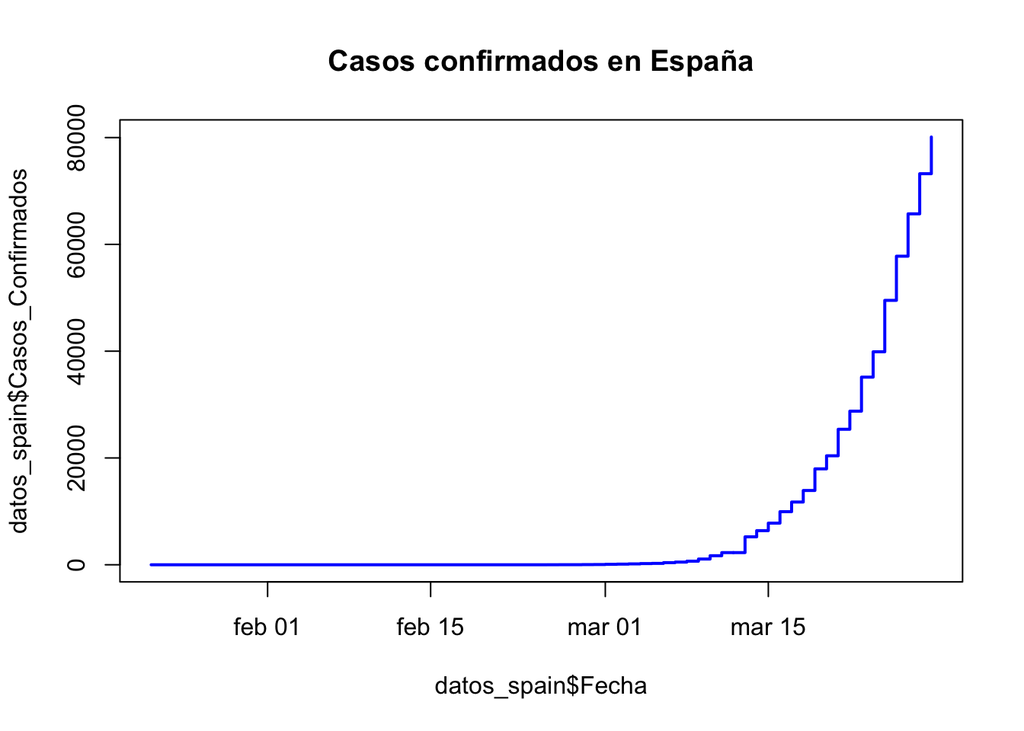

```r
datos_spain = datos[datos$Pais_Region=="Spain",]
plot(x = datos_spain$Fecha, y=datos_spain$Casos_Confirmados, main = "Casos confirmados en España", type = "s", col = "blue", lwd=2)
```

### Ejercicio extra: regresión

Queremos estudiar la evolución del número de casos confirmados en función del tiempo que ha pasado desde el origen de la pandemia. Por ello nos interesa estudiar cual de los tres siguientes modelos es el más acertado en la predicción:

- Modelo de regresión lineal (Casos_Confirmados ~ Dias):

$$\textrm{Casos_Confirmados} = \alpha\cdot\textrm{Dias}+\beta$$

- Modelo de regresión exponencial (log Casos_Confirmados ~ Dias):

$$\textrm{Casos_Confirmados} = m\cdot e^{\alpha \cdot \textrm{Dias}}$$

- Modelo de regresión potencial (log Casos_Confirmados ~ log Dias):

$$\textrm{Casos_Confirmados} = m\cdot \textrm{Dias}^\alpha$$
donde $m=e^\beta$.

En este caso queremos utilizar la función `lm` para estudiar los tres modelos. Nos centraremos solamente en el caso de España (el mismo sub data frame que has utilizado en el ejercicio 10).

- Tomando como origen de la pandemia el 22 de Enero de 2020, añade una columna `Dias` que calcule el número de días transcurridos desde esa fecha (utiliza para ello la función `difftime`). Te recomiendo que uses la función `as.numeric` para convertir esas diferencias de fechas en números, si no no podrás hacer la regresión siguiente.
- Escribe las tres ecuaciones de los modelos (calcula los parámetros indicados en los tres modelos anteriores).
- Compara y discute los tres valores del parámetro $R^2$ de cada modelo y concluye cual es el mejor modelo de los tres.
- Representa los tres modelos en un mismo gráfico utilizando el gráfico más adecuado.
- Cambia la estética del gráfico anterior para que el eje de las y abarque desde 0 hasta 1.000.000 de infectados.
- Añade una leyenda para tener una mejor idea de cual es cada modelo.
- Representa tres puntos, uno sobre cada modelo de donde nos encontramos el día de hoy.
- Según cada uno de esos tres modelos, ¿cuántos infectados cabe esperar que habrá el 20 de Abril de 2020 cuando volvamos a clase después de Semana Santa (cuando habrán pasado ya 89 días desde el origen de la pandemia)?

```r
datos_spain$Dias = as.numeric(difftime(datos_spain$Fecha, as.Date('01/22/2020', format="%m/%d/%Y"),   units = "days"))

lm(Casos_Confirmados ~ Dias, data = datos_spain[datos_spain$Casos_Confirmados > 0,]) -> mod1
summary(mod1)
```

```
##
## Call:
## lm(formula = Casos_Confirmados ~ Dias, data = datos_spain[datos_spain$Casos_Confirmados >
##     0, ])
##
## Residuals:
##    Min     1Q Median     3Q    Max
## -16743 -11200  -2288   7128  47215
##
## Coefficients:
##             Estimate Std. Error t value Pr(>|t|)
## (Intercept) -21786.4     4675.7  -4.659 2.00e-05 ***
## Dias           816.1      111.4   7.328 9.94e-10 ***
## ---
## Signif. codes:  0 '***' 0.001 '**' 0.01 '*' 0.05 '.' 0.1 ' ' 1
##
## Residual standard error: 14200 on 56 degrees of freedom
## Multiple R-squared:  0.4895, Adjusted R-squared:  0.4804
## F-statistic:  53.7 on 1 and 56 DF,  p-value: 9.937e-10
```

```r
lm(log(Casos_Confirmados) ~ Dias, data = datos_spain[datos_spain$Casos_Confirmados > 0,]) -> mod2
summary(mod2)
```

```
##
## Call:
## lm(formula = log(Casos_Confirmados) ~ Dias, data = datos_spain[datos_spain$Casos_Confirmados >
##     0, ])
##
## Residuals:
##     Min      1Q  Median      3Q     Max
## -2.6506 -0.4601  0.2122  0.6976  2.1589
##
## Coefficients:
##              Estimate Std. Error t value Pr(>|t|)
## (Intercept) -4.551357   0.347399  -13.10   <2e-16 ***
## Dias         0.239245   0.008275   28.91   <2e-16 ***
## ---
## Signif. codes:  0 '***' 0.001 '**' 0.01 '*' 0.05 '.' 0.1 ' ' 1
##
## Residual standard error: 1.055 on 56 degrees of freedom
## Multiple R-squared:  0.9372, Adjusted R-squared:  0.9361
## F-statistic: 835.9 on 1 and 56 DF,  p-value: < 2.2e-16
```

```r
lm(log(Casos_Confirmados) ~ log(Dias), data = datos_spain[datos_spain$Casos_Confirmados > 0,]) -> mod3
summary(mod3)
```

```
##
## Call:
## lm(formula = log(Casos_Confirmados) ~ log(Dias), data = datos_spain[datos_spain$Casos_Confirmados >
##     0, ])
##
## Residuals:
##     Min      1Q  Median      3Q     Max
## -3.7017 -1.3515  0.3066  1.4771  4.1819
##
## Coefficients:
##             Estimate Std. Error t value Pr(>|t|)
## (Intercept)  -20.723      1.689  -12.27   <2e-16 ***
## log(Dias)      7.184      0.473   15.19   <2e-16 ***
## ---
## Signif. codes:  0 '***' 0.001 '**' 0.01 '*' 0.05 '.' 0.1 ' ' 1
##
## Residual standard error: 1.861 on 56 degrees of freedom
## Multiple R-squared:  0.8046, Adjusted R-squared:  0.8012
## F-statistic: 230.7 on 1 and 56 DF,  p-value: < 2.2e-16
```

$$\textrm{Casos_Confirmados} = 816.1352856\cdot\textrm{Dias} -2.1786415\times 10^{4}$$
$$\textrm{Casos_Confirmados} = 0.0105529 \cdot e^{0.2392455 \cdot \textrm{Dias}}$$
$$\textrm{Casos_Confirmados} = 1.0004206\times 10^{-9}\cdot \textrm{Dias}^{7.1836471}$$

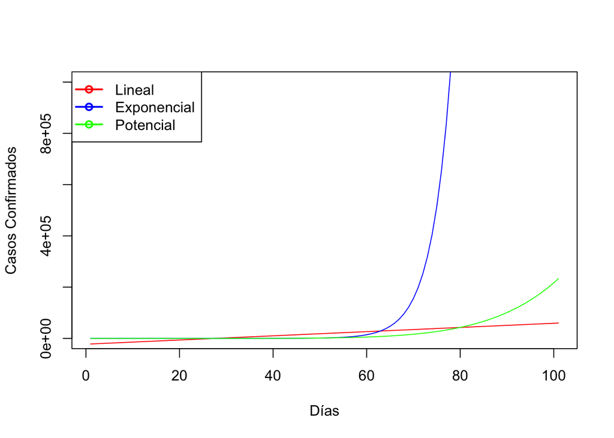

```r
dias_plot = 0:100
plot(mod1$coefficients[2]*dias_plot + mod1$coefficients[1], col = "red", type = "l", xlab="Días", ylab="Casos Confirmados", ylim=c(0,1e6))
lines(exp(mod2$coefficients[1])*exp(mod2$coefficients[2]*dias_plot)
, col = "blue")
lines(exp(mod3$coefficients[1])*dias_plot^mod3$coefficients[2]
, col = "green")
legend("topleft", c("Lineal", "Exponencial", "Potencial"), col = c("red", "blue", "green"), pch=1, lwd=2)
```